# Control de calidad de archivos fastq usando Biconductor

Estefania Mancini

28 de Marzo 2022

## Control de Calidad de Archivos FASTQ

Utilizaremos el paquete de R/Bioconductor [ShortRead](http://bioconductor.org/packages/release/bioc/html/ShortRead.html)

Si no está instalado, hay que hacerlo:

```r
if (!require("BiocManager", quietly = TRUE))
    install.packages("BiocManager")

BiocManager::install("ShortRead")
```

El primer paso que todo bioinformático que trabaja en NGS y recibe archivos fastq del servicio de secuenciación o de un repositorio público, es analizar los archivos para verificar la calidad de los mismos antes de comenzar cualquier análisis. De esta manera podemos identificar rápidamente:

- el número de lecturas de cada biblioteca
- la existencia de problemas técnicos si las muestras hubieran sido corridas en diferentes calles o aparatos y también con mucha separación en el tiempo. Lo mismo para el primer y segundo fragmento que se secuencia.
- la existencia de contaminantes, el tipo de biblioteca que se ha secuenciado (genómico, transcriptómica, amplicones) la calidad promedio de la biblioteca secuenciada.

En primer lugar elegimos el directorio de trabajo y ponemos allı́ los archivos FASTQ que descargamos de SRA.

Para ello los vamos a descargar desde SRA usando la herramienta fastq dump

```bash
wget --output-document sratoolkit.tar.gz http://ftp-trace.ncbi.nlm.nih.gov/sra/sdk/current/sratoolkit.current-ubuntu64.tar.gz
```

Luego:

```bash
  fastq-dump --split-e  SRR5264037
```

Cargamos el paquete al entorno de trabajo. Vamos a analizar la calidad del archivo fastq con una función especial para ello

```r
library(ShortRead)
setwd("~/Documents/UNR/clases/data/QC/")
countFastq("R1.fq.gz")
```

```
##          records nucleotides    scores
## R1.fq.gz 8303140   838617140 838617140
```

```r
fqQC <-qa("R1.fq.gz")
```

La lectura del archivo se guardará en el objeto . El objeto que se generó ya contiene las métricas de calidad. Podemos imprimirlo en un reporte en formato HTML.

*TIP: Verificar que el directorio donde se exporta la salida.*

```r
report(fqQC, type="html", dest="fastqQAreport-wt-short")
```

```
## [1] "fastqQAreport-wt-short/index.html"
```

Abrir el reporte en un navegador web.

*TIP: Debajo de cada gráfico se especifican las funciones con las que se han realizado*

Podemos hacerlos uno por uno:

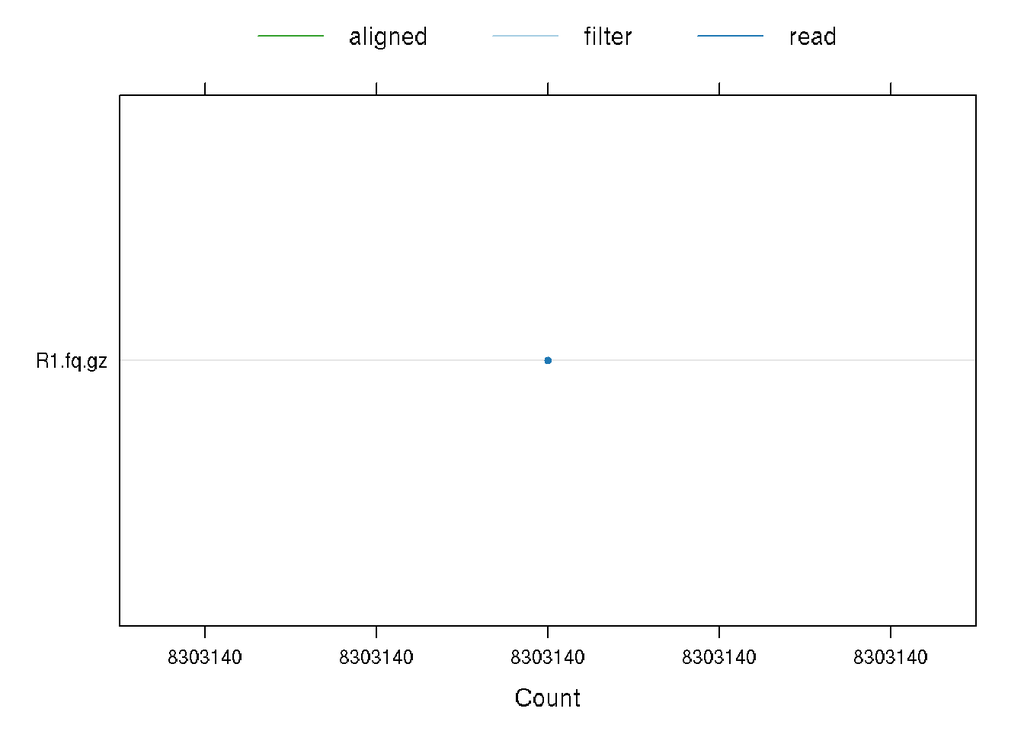

```r
ShortRead:::.plotReadCount(fqQC)
```

Este primer gráfico no es muy informativo ya que aquı́ solo estamos analizando el total de lecturas, sin tener en cuenta si han sido filtradas o alineadas. Además estamos mirando 1 sola muestra y sola lane.

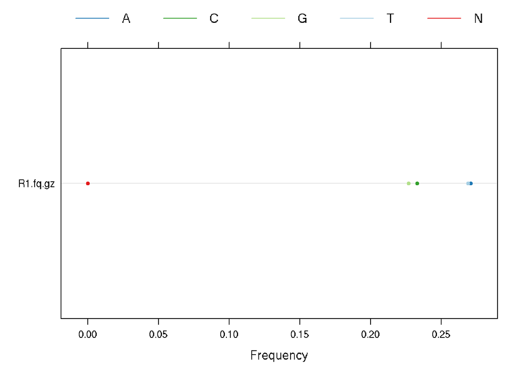

```r
ShortRead:::.plotNucleotideCount(fqQC)
```

En este segundo gráfico, podemos ver la frecuencia de aparición de cada base. Este cálculo podemos hacerlo manualmente también usando uno de los comandos que se señalan arriba.

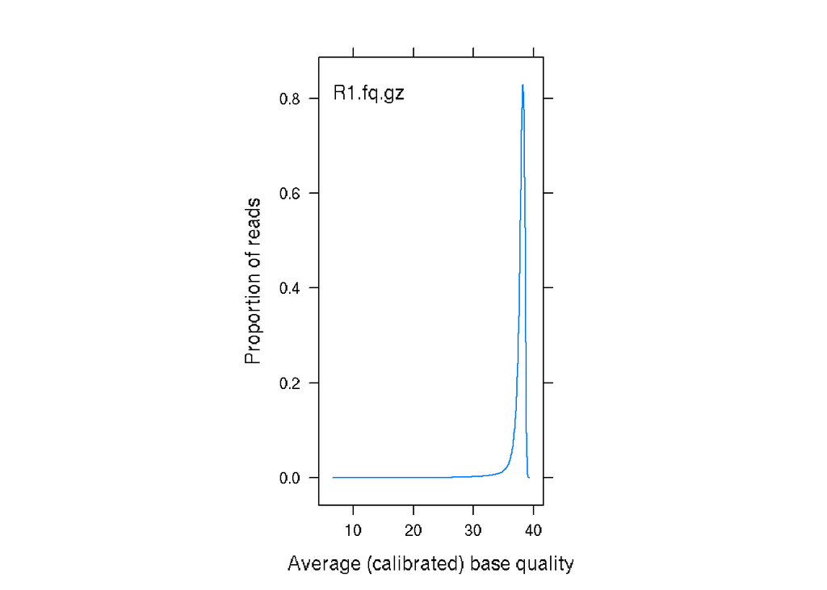

```r
df <- fqQC[["readQualityScore"]]
ShortRead:::.plotReadQuality(df[df$type=="read",])
```

En este caso observaremos la distribución de calidad en todo el archivo fastq. ¿Qué puede decir de la calidad de esta muestra? ¿Le resulta confiable para seguir trabajando?

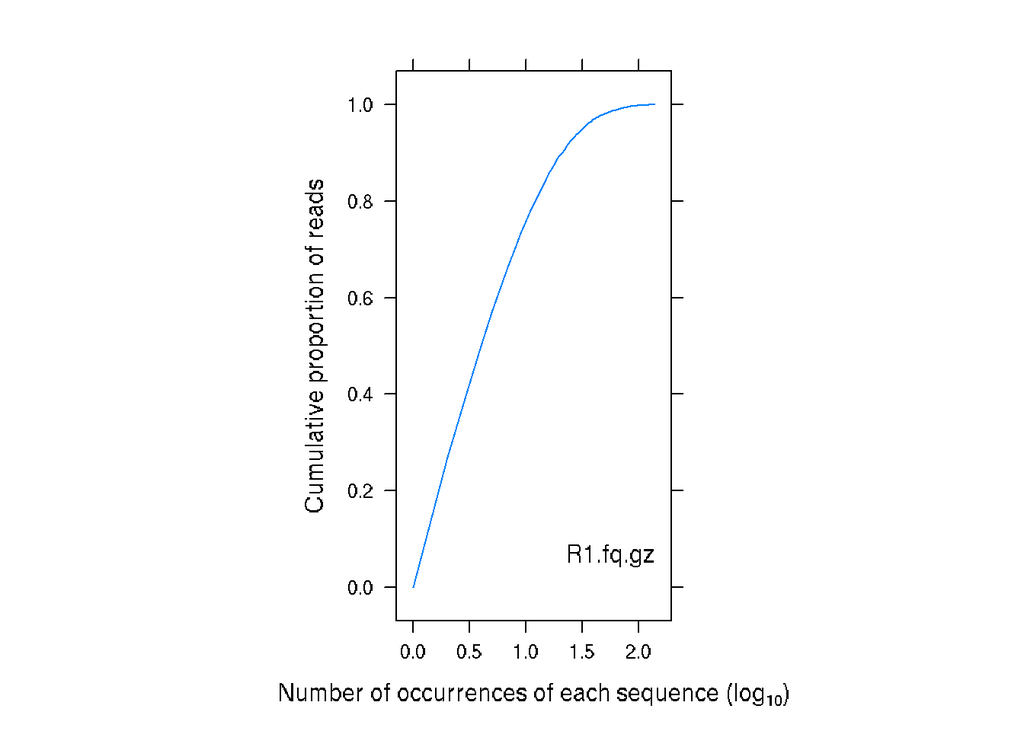

```r
df <- fqQC[["sequenceDistribution"]]
ShortRead:::.plotReadOccurrences(df[df$type=="read",], cex=.5)
```

Esta es una manera de representar la proporción de lecturas del mismo tipo. Idealmente la proporción cae abruptamente. las lecturas menos representadas suelen ser errores de secuenciación o fragmentos espúreos (lecturas infrecuentes, suelen ser ~10 % normalmente). Si hubiera lecturas demasiado sobrerepresentadas podriamos sospechar de alguna contaminación, también adaptadores, *primers*, artefactos como colas poliA, regiones altamente repetitivas, que reflejen algún error en la preparación de las muestras (5 % normalmente).

Otra manera de verlo rápidamente:

```r
ShortRead:::.freqSequences(fqQC, "read", n=10)
```

```
##                                                                                                 sequence
## 1  CAAATCTTAAACGTTTTACTTTGTGCTGCACTACTCAACCTCAATGGCCGCCTCAACAATGGCTCTCTCCTCCCCTGCCTTCGCCGGTAAGGCCGTCAAGC
## 2  CTTAAACGTTTTACTTTGTGCTGCACTACTCAACCTCAATGGCCGCCTCAACAATGGCTCTCTCCTCCCCTGCCTTCGCCGGTAAGGCCGTCAAGCTTTCC
## 3  CGGGGATGAAGAAAGAGGAGGTTAAAGTGGAGATAGAGGACGACAGTGTGCTCAAGATCAGTGGAGAGAGACACGTGGAGAAAGAGGAGAAGCAGGACACG
## 4  CAAGAAGCAAGAAAGTTAACACAACAGCTAAGAATGGATTTGGAGTTTGGAAGGTTTCCAATATTTTCAATCCTCGAAGACATGCTTGAAGCCCCTGAAGA
## 5  GCCATATTCAAATCAAGAGCCATAATCAGAAGAGTCTTTACGCATAAACATGAAACCCATAAGCTAATTGGCTTTAGCCAGAGATATCAATAGACTTAACT
## 6  CAAAAACACAAGCAACTCCGATGATAAAACTCGAACCCATTACTCAACCAGAGATCTGAATAGACTTAACATCAGCCTTCTTAGTCTCAGCCTTAGGCACC
## 7  CAATGGCTTCCTCTATGCTCTCTTCCGCTACTATGGTTGCCTCTCCGGCTCAGGCCACTATGGTCGCTCCTTTCAACGGACTTAAGTCCTCCGCTGCCTTC
## 8  CAAGAATTCGCTTGAGAACTATGCTTACAACATGAGAAACACTATCAAGGATGAGAAACTCGCACAGAAACTAACTCAAGAGGATAAGCAGAAGATTGAGA
## 9  CACAAATTCATAACACAACAAGCCAAGAAAAAAACACAAACTTAAGCACACAAGCTTTTTATTTGACACACCAAATATTTCATCTTCATCTTCATATTCAA
## 10 CAACAACAAATCTTAAACGTTTTACTTTGTGCTGCACTACTCAACCTCAATGGCCGCCTCAACAATGGCTCTCTCCTCCCCTGCCTTCGCCGGTAAGGCCG
##    count     lane
## 1    139 R1.fq.gz
## 2    123 R1.fq.gz
## 3    113 R1.fq.gz
## 4    108 R1.fq.gz
## 5    106 R1.fq.gz
## 6     99 R1.fq.gz
## 7     98 R1.fq.gz
## 8     91 R1.fq.gz
## 9     90 R1.fq.gz
## 10    88 R1.fq.gz
```

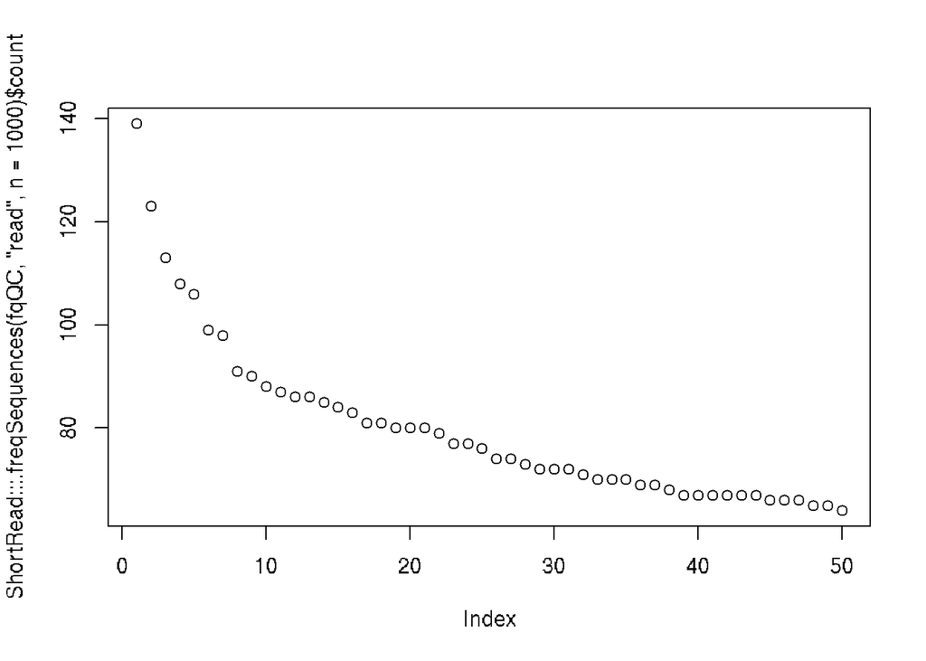

```r
#las primeras 1000 secuencias más representadas
plot(ShortRead:::.freqSequences(fqQC, "read", n=1000)$count)
```

De acuerdo a lo que vimos sobre la tecnologı́a de secuenciación, podemos analizar cómo fue la calidad del *base calling* ciclo a ciclo.

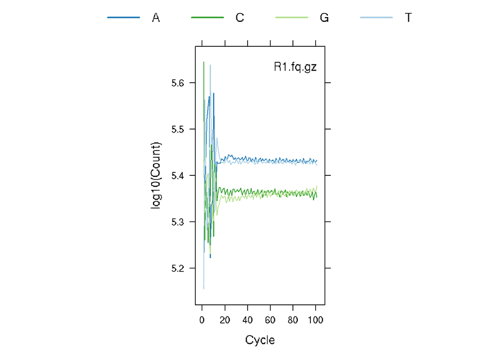

```r
perCycle <- fqQC[["perCycle"]]
ShortRead:::.plotCycleBaseCall(perCycle$baseCall)
```

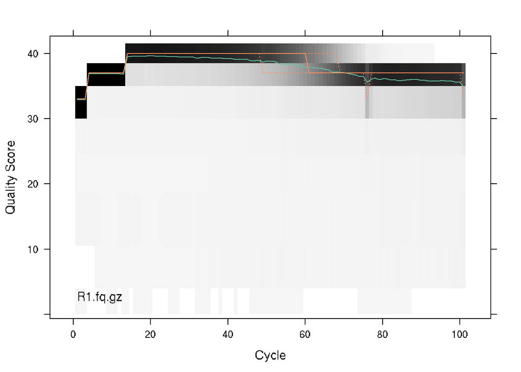

```r
ShortRead:::.plotCycleQuality(perCycle$quality)
```

- Aparece una frecuencia diferente de la esperada al azar para estas primeras bases cuando estamos trabajando con bibliotecas de RNA debido a que el proceso de pasar de RNA a cDNA requiere de *primers random* que suelen tener preferencias por algunos sitios, aunque uno esperarı́a que fuera al azar. En este punto hay que prestar atención para distinguir rápidamente qué tipo de biblioteca estamos analizando.
- Con respecto a la calidad ciclo por ciclo, los primeros ciclos en la tecnologı́a de Illumina suelen tener calidades menores a las del resto de la secuencia. No es para preocuparse, tiene relación con los algoritmos que llevan a cabo el proceso de identificación de la base a partir de las señales lumı́nicas y la identificación de los *clusters*.
- ¿Qué podemos decir del archivo fastq que se ha analizado? ¿Qué información relevante nos otorgan este tipo de análisis?

## Otras herramientas

Una de las herramientas más utilizadas es [FastQC](https://www.bioinformatics.babraham.ac.uk/projects/fastqc/). En la sección de ayuda se puede profundizar sobre las conclusiones. Se puede agregar fácilmente con la herramienta [MULTIQC](https://multiqc.info/) *(ver ejemplo en clase teórica)*

## Vignette

En la [vignette](http://bioconductor.org/packages/release/bioc/vignettes/ShortRead/inst/doc/Overview.pdf) hay más funcionalidades para explorar.

## Repaso

Repetir el ejercicio con el **R2.fq.gz** y completar el [cuestionario](https://forms.gle/XbFiUAZMkVPWZsMw5)